# Renterisiko

Hvor meget — og hvor på kurven?

Niklas Lehmann Jensen

## Introduktion

#### Dagens spørgsmål

- Hvordan måler **Macaulay-varighed**, hvor i tiden værdien ligger?
- Hvordan omsættes varighed til følsomhed i **%, kurspoint og bp**?
- Hvorfor er varighed kun **lineær** — og hvad tilføjer **konveksitet**?
- Hvorfor fordele risikoen på **punkter** på kurven?

#### Læringsmål

- Macaulay-varighed som **vægtet gennemsnitlig betalingstid**
- Modificeret varighed & kronevarighed som følsomhedsmål
- Skelne **procent, procentpoint og basispunkter**
- Hvorfor varighed kun er en **lineær approksimation**
- Konveksitet som **krumningen** i kurs-rente-sammenhængen
- Porteføljerisiko som **vægtede gennemsnit**
- Idéen bag **Fisher–Weil** og **nøglerentevarighed**

## Varighed

#### Macaulay: gennemsnitlig betalingstid

**Definition**

**Macaulay-varighed** = den vægtede gennemsnitlige tid til betalingerne, hvor vægtene er betalingernes **nutidsværdier** som andel af prisen.

$$D = \sum_{t=1}^{N} w_t\cdot t, \qquad w_t = \frac{PV(CF_t)}{P}$$

- Betalingsrækkens **tidsmæssige tyngdepunkt** — løbetid $\neq$ varighed

#### Samme løbetid, forskellig varighed

[figure not shown]

Stående: $D = 8{,}867$ år

[figure not shown]

Serie: $D = 4{,}948$ år

- Begge udløber om ~10 år — men den store **slutbetaling** trækker den ståendes tyngdepunkt ud

## Fra tid til prisfølsomhed

#### Enhedsfælden

**Enhedsfælden i renterisiko**

1 procentpoint = **100 basispunkter** = **0,01** i decimaltal. Forkerte enheder giver typisk fejl med **faktor 100** i varighed, BPV og konveksitet.

- “Renten stiger med 1 %” undgås — tvetydigt (relativ vs. procentpoint)

#### Modificeret varighed

$$MD = \frac{D}{1+y} = \frac{8{,}867}{1{,}0245} = 8{,}655$$

$$\frac{\Delta P}{P} \approx -MD\cdot \Delta y \quad (\Delta y \text{ i decimaltal})$$

- +1 pp $\Rightarrow$ kursen falder **~8,655 %** (og omvendt)

#### Kronevarighed & BPV

$$d = MD\cdot \frac{K}{100} = 8{,}655\cdot\frac{98{,}696}{100} = 8{,}542$$

$$BPV = \frac{d}{100} = 0{,}08542$$

- $d$ = **kurspoint pr. procentpoint** · BPV = **kurspoint pr. basispunkt**

#### Immunisering

- **Kursrisiko** (rente op → kurs ned) og **reinvesteringsrisiko** (rente ned → lavere reinvestering) trækker **modsat**
- Balancerer, når **horisont ≈ varighed** (~8,867 år)

[figure not shown]

## Konveksitet

#### Kurven er krum

| Renteændring | Kursændring |
| --- | --- |
| $-1$ pp | $+8{,}995$ |
| $+1$ pp | $-8{,}122$ |

Kronevarighed $8{,}542$ ligger **midt imellem** → asymmetri

[figure not shown]

#### Kronekonveksitet

$$\Delta K \approx -d\cdot\Delta y_{pp} + \tfrac{1}{2}C\cdot(\Delta y_{pp})^2, \qquad C = 0{,}872$$

- Forbedret ved $-1$ pp: $-8{,}542(-1)+\tfrac12(0{,}872) = \mathbf{8{,}978}$ (faktisk 8,995)
- $\Delta y_{pp}$ i **procentpoint** her — ikke decimaltal (enhedsfælden!)

#### Hvorfor konveksitet betyder noget

- Positiv konveksitet: **taber mindre** op, **vinder mere** ned
- Men konveksitet har en **pris** (dyrere obligation)
- Vigtigst ved **store** renteudsving

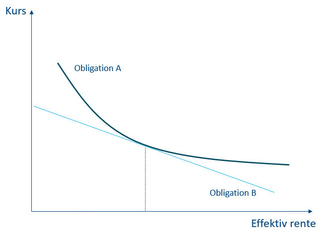

## Porteføljer

#### Renterisiko på porteføljer

|  | Nom. | Kurs | Markedsv. | Mac. | MD | $d$ | $C$ |
| --- | --- | --- | --- | --- | --- | --- | --- |
| Obl. 1 | 10 mio. | 99,3 | 9,93 | 2,20 | 2,18 | 2,16 | 0,14 |
| Obl. 2 | 15 mio. | 101,5 | 15,23 | 4,80 | 4,73 | 4,80 | 0,34 |
| Obl. 3 | 25 mio. | 102,8 | 25,70 | 10,50 | 10,30 | 10,59 | 1,20 |
| **Portefølje** | **50 mio.** |  | **50,86** | **7,17** | **7,05** | **7,17** | **0,73** |

- Mac./MD vægtes med **markedsværdi** · $d$/BPV/$C$ vægtes med **nominel**

## Rentekurven som mål

#### Fisher–Weil-varighed

**Definition**

**Fisher–Weil-varighed** diskonterer hver betaling med **nulkuponrenten** for dens egen løbetid — i stedet for én effektiv rente.

- Mere konsistent, når kurven **ikke er flad**
- Måler stadig primært et **parallelt** skift → leder til nøglerenter

#### Tre tilgange til varighed

[figure not shown]

#### Nøglerentevarighed / delta-vektorer

- Ét samlet tal skjuler **hvor** risikoen ligger
- Fordel risikoen på **nøglerenter** (fx 1, 3, 5, 10 år)
- Stød ét punkt ad gangen — aftager lineært mod nabopunkter

[figure not shown]

#### Eksempel: kort vs. langt stød

3-årig obligation, basis-NV $= 100{,}11$:

- Kort stød → kursfald **0,06**
- Langt stød → kursfald **2,72**
- Sum $0{,}06 + 2{,}72 = \mathbf{2{,}78}$ = parallelskift

[figure not shown]

## Afrunding

#### The Takeaways

1. Macaulay-varighed er betalingernes **nutidsværdivægtede gennemsnitstid** — ikke løbetiden.
2. Modificeret varighed, kronevarighed og BPV er **samme følsomhed** i forskellige enheder.
3. **Konveksitet** korrigerer varighed, fordi kurs-rente-sammenhængen er krum.
4. **Fisher–Weil** og **nøglerentevarighed** bruger kurven til at vise, *hvor* risikoen ligger.

#### Bro: realkredit gør varighed dynamisk

- Hidtil: **fast** betalingsrække → varighed & konveksitet er faste tal
- Realkredit: låntagere kan **konvertere og afdrage** → betalingsrækken er usikker
- → varighed og konveksitet bliver **dynamiske** (kapitel 5–7)

#### Øvelser

1. Løbetid er ikke varighed (stående vs. serie)
2. Modificeret varighed, kronevarighed & BPV
3. Konveksitet & forbedret approksimation
4. Immunisering & horisont
5. Porteføljerisiko: de to vægtningsregler
6. Fisher–Weil & nøglerentevarighed